# Hazard APIs

Center for Computational Toxicology and Exposure

## Introduction

In this vignette, [CCTE Hazard APIs](https://api-ccte.epa.gov/docs/hazard.html) will be explored.

**NOTE:** Please see the introductory vignette for an overview of the *ccdR* package and initial set up instruction with API key storage.

Data for the Hazard APIs comes ToxValDB. The Toxicity Value Database (ToxValDB) includes data on thousands of chemicals from tens of thousands of records, with an emphasis on quantitative estimates of relevant points-of-departure from in vivo toxicology studies, such as no- and low-observable adverse effect levels, screening levels, reference doses, tolerable daily intake, etc.

This resource is a compilation of information sourced from multiple public datasets, databases and open literature. More information on ToxValDB can be found at https://www.epa.gov/comptox-tools/downloadable-computational-toxicology-data#AT.

## Functions

Several ccdR functions are used to access the CCTE Hazard API data.

### Hazard Resource

#### Get Hazard Data by DTXSID

`get_hazard_by_dtxsid()` retrieves all hazard data, both human and EcoTox data.

```r
res_dt <- get_hazard_by_dtxsid(DTXSID = 'DTXSID7020182')
```

#### Get Human Hazard Data by DTXSID

`get_human_hazard_by_dtxsid()` retrieves only human hazard data.

```r
res_dt <- get_human_hazard_by_dtxsid(DTXSID = 'DTXSID7020182')
```

#### Get EcoTox Hazard Data by DTXSID

`get_ecotox_hazard_by_dtxsid()` retrieves only ecological toxicity hazard data.

```r
res_dt <- get_ecotox_hazard_by_dtxsid(DTXSID = 'DTXSID7020182')
```

### Skin Eye Resource

`get_skin_eye_hazard()` retrieves hazard data specific to skin and eye hazard.

```r
res_dt <- get_skin_eye_hazard(DTXSID = 'DTXSID7020182')
```

### Cancer Resource

`get_cancer_hazard()` retrieves cancer hazard data.

```r
res_dt <- get_cancer_hazard(DTXSID = 'DTXSID7020182')
```

### Genetox Resource

`get_genetox_summary()` retrieves summary level data for genotoxicity data associated to a chemical.

```r
res_dt <- get_genetox_summary(DTXSID = 'DTXSID7020182')
```

`get_genetox_detail()` retrieves more detailed genetox data for a chemical than is provided on the summary level.

```r
res_dt <- get_genetox_details(DTXSID = 'DTXSID7020182')
```

## Example Use Case: Comparing Hazard Data Across Chemical Lists

The fourth Drinking Water Contaminant Candidate List (CCL4) is a set of chemicals that “…are not subject to any proposed or promulgated national primary drinking water regulations, but are known or anticipated to occur in public water systems….” Moreover, this list “…was announced on November 17, 2016. The CCL 4 includes 97 chemicals or chemical groups and 12 microbial contaminants….” The National-Scale Air Toxics Assessments (NATA) is “… EPA’s ongoing comprehensive evaluation of air toxics in the United States… a state-of-the-science screening tool for State/Local/Tribal agencies to prioritize pollutants, emission sources and locations of interest for further study in order to gain a better understanding of risks… use general information about sources to develop estimates of risks which are more likely to overestimate impacts than underestimate them….”

These lists can be found in the CCD at CCL4 with additional information at [CCL4 information](https://www.epa.gov/ccl/contaminant-candidate-list-4-ccl-4-0) and NATADB with additional information at [NATA information](https://www.epa.gov/national-air-toxics-assessment). The quotes from the previous paragraph were excerpted from list detail descriptions found using the CCD links.

In this example use case, hazard data will be compared between a water contaminant priority and an air toxics list.

### Obtain Lists of Chemicals

First, confirm the chemical list to query.

```r
options(width = 100)
ccl4_information <- get_public_chemical_list_by_name('CCL4')
print(ccl4_information, trunc.cols = TRUE)
```

```
#>    id    type                                    label visibility
#> 1 443 federal WATER|EPA: Chemical Contaminants - CCL 4     PUBLIC
#>                                                                                                                                                                                                                                                                                                          …
#> 1 The Contaminant Candidate List (CCL) is a list of contaminants that, at the time of publication, are not subject to any proposed or promulgated national primary drinking water regulations, but are known or anticipated to occur in public water systems. Contaminants listed on the CCL may require …
#>              updatedAt listName chemicalCount            createdAt
#> 1 2022-10-26T21:14:27Z     CCL4           100 2017-12-28T17:58:36Z
#>                                                                                                                                              shortDescription
#> 1 The Contaminant Candidate List (CCL) is a list of contaminants that are known or anticipated to occur in public water systems. Version 4 is known as CCL 4.
```

```r
natadb_information <- get_public_chemical_list_by_name('NATADB')
print(natadb_information, trunc.cols = TRUE)
```

```
#>    id    type                                            label visibility
#> 1 454 federal EPA: National-Scale Air Toxics Assessment (NATA)     PUBLIC
#>                                                                                                                                                                                                                                                                                                          …
#> 1 The National-Scale Air Toxics Assessment (NATA) is EPA's ongoing comprehensive evaluation of air toxics in the United States. EPA developed the NATA as a state-of-the-science screening tool for State/Local/Tribal Agencies to prioritize pollutants, emission sources and locations of interest for …
#>              updatedAt listName chemicalCount            createdAt
#> 1 2018-11-16T21:42:01Z   NATADB           163 2018-02-21T12:04:16Z
#>                                                                                                                shortDescription
#> 1 The National-Scale Air Toxics Assessment (NATA) is EPA's ongoing comprehensive evaluation of air toxics in the United States.
```

Next, retrieve the list of chemicals associated with each list.

```r
ccl4 <- get_chemicals_in_list('CCL4')
ccl4 <- data.table::as.data.table(ccl4)

natadb <- get_chemicals_in_list('NATADB')
natadb <- data.table::as.data.table(natadb)
```

### Review Genotoxicity Data for a Single Chemical

Using the standard CompTox Chemicals Dashboard approach to access genotoxicity hazard data, one would navigate to the individual chemical page as shown below.

[figure not shown]

*Figure 1: CCD Navigation to Hazard Data>Genotoxicity Plot*

Figure 2 shows the genotoxicity section of the hazard tab for Bisphenol A. This page provides a summary of available genotoxicity data as well as individual reports and samples of such data.

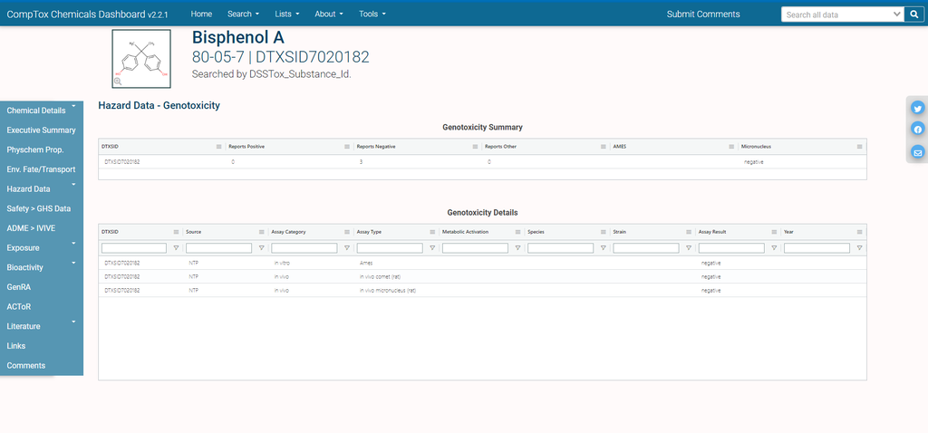

*Figure 2: CCD Hazard Data>Genotoxicity for Bisphenol A*

The CCTE APIs streamline the process of retrieving this information in a programmatic fashion. Figure 3 shows the particular set of genotoxicity resources available in the `Hazard` endpoints of the CCTE APIs. There are both summary and detail resources, reflecting the information one can find on the CompTox Chemicals Dashboard Genotoxicity page for a given chemical.

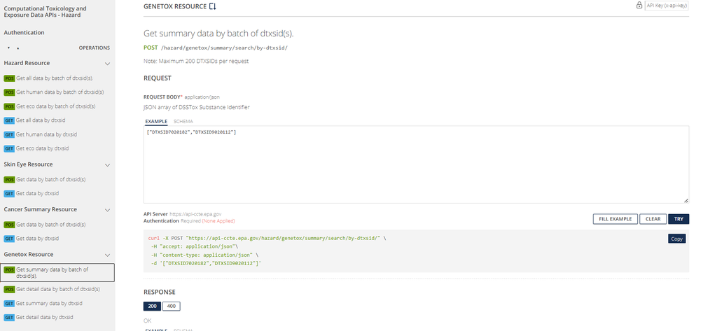

*Figure 3: CCTE Hazard APIs for Genotoxicity Endpoints*

### Review Genotoxicity Data for Chemical Lists

The function `get_genetox_summary()` is used to access summary genotoxicity information per chemical. To query a list of chemicals, rather than searching individually for each chemical, the batch search version of the function, `get_genetox_summary_batch()`, can be used to access these details.

First, pull the data.

```r
ccl4_genotox <- get_genetox_summary_batch(DTXSID = ccl4$dtxsid)
natadb_genetox <- get_genetox_summary_batch(DTXSID = natadb$dtxsid)
```

Next, it may be helpful to examine the dimensions and column names of the output.

```r
dim(ccl4_genotox)
```

```
#> [1] 71  7
```

```r
dim(natadb_genetox)
```

```
#> [1] 153   7
```

```r
colnames(ccl4_genotox)
```

```
#> [1] "id"              "dtxsid"          "reportsPositive" "reportsNegative" "reportsOther"
#> [6] "ames"            "micronucleus"
```

```r
head(ccl4_genotox)
```

```
#>       id        dtxsid reportsPositive reportsNegative reportsOther ames micronucleus
#> 1: 16410 DTXSID0020153              26               5            1    -     positive
#> 2: 20381 DTXSID0020446               0              12            0    -     negative
#> 3: 21212 DTXSID0020573               3              14            0    -     negative
#> 4: 23984 DTXSID0020600              20               0            1    -     positive
#> 5: 23751 DTXSID0020814               1               0            0    -            -
#> 6: 18199 DTXSID0021464               9              11            0    -     positive
```

The information returned is of the first variety highlighted in the Figure 2, that is, summary data on the available genotoxicity data for each chemical. Observe genotoxicity data was returned for 71 chemicals from the CCL4 chemical list and 153 from the NATA chemical list. Chemicals missing genotoxicity information are noted.

```r
ccl4[!(dtxsid %in% ccl4_genotox$dtxsid),
     .(dtxsid, casrn, preferredName, molFormula)]
```

```
#>              dtxsid       casrn             preferredName    molFormula
#>  1: DTXSID001024118  77238-39-2               Microcystin          <NA>
#>  2:   DTXSID0024052  55290-64-7                Dimethipin     C6H10O4S2
#>  3:   DTXSID0032578  59669-26-0                Thiodicarb  C10H18N4O4S3
#>  4:   DTXSID1037484 194992-44-4             Acetochlor OA     C14H19NO4
#>  5:   DTXSID1037486 171262-17-2 2-[(2,6-Diethylphenyl)(me     C14H19NO4
#>  6:   DTXSID1037567 171118-09-5           Metolachlor ESA    C15H23NO5S
#>  7:   DTXSID2022333    135-98-8          sec-Butylbenzene        C10H14
#>  8:   DTXSID2031083 143545-90-8        Cylindrospermopsin   C15H21N5O7S
#>  9:   DTXSID2037506  16655-82-6       3-Hydroxycarbofuran     C12H15NO4
#> 10:   DTXSID2052156    517-09-9                 Equilenin      C18H18O2
#> 11:   DTXSID3021857  25154-52-3             n-Nonylphenol       C15H24O
#> 12:   DTXSID3034458  99129-21-2                 Clethodim  C17H26ClNO3S
#> 13:   DTXSID3042219    103-65-1             Propylbenzene         C9H12
#> 14:   DTXSID3073137  14866-68-3                  Chlorate          ClO3
```

[output cut: 16 more lines]

```r
natadb[!(dtxsid %in% natadb_genetox$dtxsid),
       .(dtxsid, casrn, preferredName, molFormula)]
```

```
#>             dtxsid        casrn             preferredName molFormula
#>  1: DTXSID00872421 NOCAS_872421     Lead & Lead Compounds       <NA>
#>  2:  DTXSID1020273    7782-50-5                  Chlorine        Cl2
#>  3: DTXSID10872417 NOCAS_872417 Cadmium & Cadmium Compoun       <NA>
#>  4: DTXSID30872414 NOCAS_872414 Antimony & Antimony Compo       <NA>
#>  5: DTXSID30872419 NOCAS_872419 Cobalt & Cobalt Compounds       <NA>
#>  6: DTXSID40872425 NOCAS_872425 Nickel & Nickel Compounds       <NA>
#>  7:  DTXSID5024267    1336-36-3 Polychlorinated biphenyls       <NA>
#>  8:  DTXSID7020687     608-73-1 1,2,3,4,5,6-Hexachlorocyc    C6H6Cl6
#>  9:  DTXSID7023984  NOCAS_23984       Coke oven emissions       <NA>
#> 10: DTXSID90872415 NOCAS_872415 Arsenic & Arsenic Compoun       <NA>
```

Now, genotoxicity details of the chemicals in each chemical list are returned using the function `get_genetox_details_batch()`.

```r
ccl4_genetox_details <- get_genetox_details_batch(DTXSID = ccl4$dtxsid)
natadb_genetox_details <- get_genetox_details_batch(DTXSID = natadb$dtxsid)
```

If inspecting the first chemical in each set of results, DTXSID0020153, notice that the information is identical in each case as this information is chemical specific and not chemical list specific.

```r
identical(ccl4_genetox_details[dtxsid %in% 'DTXSID0020153', ],
          natadb_genetox_details[dtxsid %in% 'DTXSID0020153', ])
```

```
#> [1] TRUE
```

Assays present for chemicals in each chemical list can be explored. First, determine the unique values of the `assayCategory` column and then group by these values and determine the number of unique assays for each `assayCategory` value.

```r
ccl4_genetox_details[, unique(assayCategory)]
```

```
#> [1] "in vitro" "ND"       "in vivo"
```

```r
natadb_genetox_details[, unique(assayCategory)]
```

```
#> [1] "in vitro" "ND"       "in vivo"
```

```r
ccl4_genetox_details[, unique(assayType)]
```

```
#>  [1] "InVivoMN"
#>  [2] "Overall"
#>  [3] "bacterial reverse mutation assay"
#>  [4] "micronucleus assay"
#>  [5] "Ames"
#>  [6] "InVitroCA"
#>  [7] "InVitroMLA"
#>  [8] "InVitroMN"
#>  [9] "Cell transformation, clonal assay"
#> [10] "Forward and reverse gene mutation, host-mediated assay"
#> [11] "Histidine reverse gene mutation, Ames assay"
#> [12] "Micronucleus test, chromosome aberrations"
#> [13] "Mitotic recombination or gene conversion"
#> [14] "Rec-assay, DNA effects (bacterial DNA repair)"
#> [15] "Rec-assay, spot test, DNA effects (bacterial DNA repair)"
```

[output cut: 75 more lines]

```r
natadb_genetox_details[, unique(assayType)]
```

```
#>   [1] "InVivoMN"
#>   [2] "Overall"
#>   [3] "bacterial reverse mutation assay"
#>   [4] "micronucleus assay"
#>   [5] "Ames"
#>   [6] "InVitroCA"
#>   [7] "InVitroMLA"
#>   [8] "InVitroMN"
#>   [9] "Cell transformation, clonal assay"
#>  [10] "Forward and reverse gene mutation, host-mediated assay"
#>  [11] "Histidine reverse gene mutation, Ames assay"
#>  [12] "Micronucleus test, chromosome aberrations"
#>  [13] "Mitotic recombination or gene conversion"
#>  [14] "Rec-assay, DNA effects (bacterial DNA repair)"
#>  [15] "Rec-assay, spot test, DNA effects (bacterial DNA repair)"
```

[output cut: 99 more lines]

Next, determine the number of assays per unique `assayCategory` value, count the number of assay results and grouping by `assayCategory`, and `assayType`, and also examine the different numbers of `assayCategory` and `assayTypes` values used for both chemical lists.

```r
ccl4_genetox_details[, .(Assays = length(unique(assayType))),
                     by = .(assayCategory)]
```

```
#>    assayCategory Assays
#> 1:      in vitro     65
#> 2:            ND      3
#> 3:       in vivo     22
```

```r
natadb_genetox_details[, .(Assays = length(unique(assayType))),
                       by = .(assayCategory)]
```

```
#>    assayCategory Assays
#> 1:      in vitro     83
#> 2:            ND      3
#> 3:       in vivo     28
```

```r
ccl4_genetox_details[, .N, by = .(assayCategory, assayType, assayResult)]
```

```
#>      assayCategory                 assayType assayResult  N
#>   1:      in vitro                  InVivoMN    negative 10
#>   2:            ND                   Overall    positive  5
#>   3:      in vitro bacterial reverse mutatio    positive 39
#>   4:       in vivo        micronucleus assay    negative 36
#>   5:       in vivo        micronucleus assay   equivocal  1
#>  ---
#> 149:      in vitro Heritable translocation t    negative  1
#> 150:      in vitro     Mitotic recombination    positive  1
#> 151:      in vitro Aneuploidy, sex chromosom    negative  1
#> 152:      in vitro Aneuploidy, whole sex chr    positive  1
#> 153:      in vitro          fluctuation test    negative  2
```

```r
ccl4_genetox_details[, .N, by = .(assayCategory)]
```

```
#>    assayCategory   N
#> 1:      in vitro 815
#> 2:            ND  38
#> 3:       in vivo 188
```

```r
ccl4_genetox_details[assayCategory == 'in vitro', .N, by = .(assayType)]
```

```
#>                     assayType   N
#>  1:                  InVivoMN  28
#>  2: bacterial reverse mutatio 165
#>  3:                      Ames  88
#>  4:                 InVitroCA  31
#>  5:                InVitroMLA  24
#>  6:                 InVitroMN   6
#>  7: Cell transformation, clon   8
#>  8: Forward and reverse gene    7
#>  9: Histidine reverse gene mu  19
#> 10: Micronucleus test, chromo   8
#> 11: Mitotic recombination or   18
#> 12: Rec-assay, DNA effects (b  15
#> 13: Rec-assay, spot test, DNA   2
#> 14: Sister-chromatid exchange  41
```

[output cut: 52 more lines]

```r
ccl4_genetox_details[assayCategory == 'ND', .N, by = .(assayType)]
```

```
#>                    assayType  N
#> 1:                   Overall  5
#> 2: In vivo carcinogenicity s 23
#> 3:                transgenic 10
```

```r
ccl4_genetox_details[assayCategory == 'in vivo', .N, by = .(assayType)]
```

```
#>                     assayType  N
#>  1:        micronucleus assay 46
#>  2: Unscheduled DNA synthesis  9
#>  3: in vivo micronucleus (mou 19
#>  4: in vivo micronucleus (rat  9
#>  5:          Sperm morphology  9
#>  6:                  InVivoCA 14
#>  7:                 InVivoUDS 11
#>  8:      Dominant lethal test  5
#>  9: Unscheduled DNA synthesis  3
#> 10: mammalian germ cell cytog  2
#> 11:               DNA Binding  1
#> 12: rodent dominant lethal as 15
#> 13: unscheduled DNA synthesis  6
#> 14: Chromosome aberrations in  2
#> 15:           InVivoDNADamage  7
#> 16:      In Vivo Micronucleus  1
#> 17: Micronucleus and sister c  2
#> 18:     in vivo comet (mouse)  1
#> 19:       in vivo comet (rat)  3
#> 20:      DNA Covalent Binding 12
#> 21: In Vivo Chromosome Aberra  4
#> 22: In Vivo Mammalian Mutagen  7
#>                     assayType  N
```

```r
natadb_genetox_details[, .N, by = .(assayCategory, assayType, assayResult)]
```

```
#>      assayCategory                 assayType assayResult  N
#>   1:      in vitro                  InVivoMN    negative 40
#>   2:            ND                   Overall    positive 16
#>   3:      in vitro bacterial reverse mutatio    positive 93
#>   4:       in vivo        micronucleus assay    negative 76
#>   5:       in vivo        micronucleus assay   equivocal  4
#>  ---
#> 194:      in vitro Heritable translocation t    negative  2
#> 195:       in vivo     mammalian comet assay   equivocal  1
#> 196:      in vitro mammalian cell gene mutat    positive  1
#> 197:      in vitro in vitro mammalian cell t    positive  1
#> 198:      in vitro     Mitotic recombination    positive  1
```

```r
natadb_genetox_details[, .N, by = .(assayCategory)]
```

```
#>    assayCategory    N
#> 1:      in vitro 2112
#> 2:            ND  100
#> 3:       in vivo  435
```

```r
natadb_genetox_details[assayCategory == 'in vitro', .N, by = .(assayType)]
```

```
#>                     assayType   N
#>  1:                  InVivoMN  89
#>  2: bacterial reverse mutatio 362
#>  3:                      Ames 258
#>  4:                 InVitroCA  98
#>  5:                InVitroMLA  85
#>  6:                 InVitroMN  20
#>  7: Cell transformation, clon  14
#>  8: Forward and reverse gene   17
#>  9: Histidine reverse gene mu  55
#> 10: Micronucleus test, chromo  33
#> 11: Mitotic recombination or   47
#> 12: Rec-assay, DNA effects (b  34
#> 13: Rec-assay, spot test, DNA   6
#> 14: Sister-chromatid exchange  98
```

[output cut: 70 more lines]

```r
natadb_genetox_details[assayCategory == 'ND', .N, by = .(assayType)]
```

```
#>                    assayType  N
#> 1:                   Overall 16
#> 2: In vivo carcinogenicity s 66
#> 3:                transgenic 18
```

```r
natadb_genetox_details[assayCategory == 'in vivo', .N, by = .(assayType)]
```

```
#>                     assayType   N
#>  1:        micronucleus assay 105
#>  2: Unscheduled DNA synthesis  27
#>  3: rodent dominant lethal as  31
#>  4:                 InVivoUDS  33
#>  5:                  InVivoCA  37
#>  6:      Dominant lethal test  14
#>  7: Unscheduled DNA synthesis   5
#>  8: In Vivo Chromosome Aberra   5
#>  9: In Vivo Mammalian Mutagen   6
#> 10:      In Vivo Micronucleus  11
#> 11:           InVivoDNADamage  23
#> 12: in vivo micronucleus (mou  51
#> 13:          Sperm morphology  25
#> 14:               DNA Binding   1
#> 15: unscheduled DNA synthesis  18
#> 16:     in vivo comet (mouse)   4
#> 17: Chromosome aberrations in   9
#> 18:       in vivo comet (rat)   3
#> 19: in vivo micronucleus (rat   9
#> 20: mammalian erythrocyte mic   2
#> 21: heritable translocation a   2
#> 22: Micronucleus and sister c   2
#> 23: bone marrow chromosome ab   1
#> 24: Chromosome aberrations, i   2
#> 25:      DNA adduct formation   1
#> 26:      DNA Covalent Binding   1
#> 27:     mammalian comet assay   6
#> 28: mammalian germ cell cytog   1
#>                     assayType   N
```

Observe that there are 90 unique assays for CCl4 and 114 unique assays for NATADB. The different assay categories are “in vitro”, “ND”, and “in vivo”, with 65 unique “in vitro” assays for CCl4 and 83 for NATADB, 3 unique “ND” assays for CCL4 and 3 for NATADB, and 22 unique “in vivo” assays for CCL4 and 28 for NATADB.

One may be interested in looking at the number of chemicals for which an assay resulted in a positive or negative result. To assess this, group by `assayResult` and determine the number of unique `dtxsid` values associated with each `assayResult` value.

```r
ccl4_genetox_details[, .(DTXSIDs = length(unique(dtxsid))), by = .(assayResult)]
```

```
#>    assayResult DTXSIDs
#> 1:    negative      64
#> 2:    positive      53
#> 3:   equivocal      15
```

```r
natadb_genetox_details[, .(DTXSIDs = length(unique(dtxsid))),
                       by = .(assayResult)]
```

```
#>    assayResult DTXSIDs
#> 1:    negative     141
#> 2:    positive     130
#> 3:   equivocal      48
```

Next, determine the chemicals from each chemical list that are known to have genotoxic effects. For this, examine which chemicals produce at least one positive response in the `assayResult` column.

```r
ccl4_genetox_details[, .(is_positive = any(assayResult == 'positive')),
                     by = .(dtxsid)][is_positive == TRUE, dtxsid]
```

```
#>  [1] "DTXSID0020153" "DTXSID0020573" "DTXSID0020600" "DTXSID0020814" "DTXSID0021464" "DTXSID0021541"
#>  [7] "DTXSID0024341" "DTXSID1021407" "DTXSID1021740" "DTXSID1021798" "DTXSID1024338" "DTXSID1026164"
#> [13] "DTXSID1031040" "DTXSID2021028" "DTXSID2021317" "DTXSID2021731" "DTXSID3020203" "DTXSID3020702"
#> [19] "DTXSID3020833" "DTXSID3024869" "DTXSID3031864" "DTXSID4020533" "DTXSID4021503" "DTXSID4022361"
#> [25] "DTXSID4022367" "DTXSID5020023" "DTXSID5020576" "DTXSID5020601" "DTXSID5021207" "DTXSID5024182"
#> [31] "DTXSID5039224" "DTXSID6020301" "DTXSID6021030" "DTXSID6021032" "DTXSID6022422" "DTXSID7020005"
#> [37] "DTXSID7020215" "DTXSID7020637" "DTXSID7021029" "DTXSID8020044" "DTXSID8020090" "DTXSID8020832"
#> [43] "DTXSID8021062" "DTXSID8023846" "DTXSID8023848" "DTXSID8025541" "DTXSID8031865" "DTXSID9020243"
#> [49] "DTXSID9021390" "DTXSID9021427" "DTXSID9022366" "DTXSID9023380" "DTXSID9023914"
```

```r
natadb_genetox_details[, .(is_positive = any(assayResult == 'positive')),
                       by = .(dtxsid)][is_positive == TRUE, dtxsid]
```

```
#>   [1] "DTXSID0020153" "DTXSID0020448" "DTXSID0020523" "DTXSID0020529" "DTXSID0020600"
#>   [6] "DTXSID0020868" "DTXSID0021381" "DTXSID0021383" "DTXSID0021541" "DTXSID0021834"
#>  [11] "DTXSID0021965" "DTXSID0024187" "DTXSID0039227" "DTXSID0039229" "DTXSID1020148"
#>  [16] "DTXSID1020302" "DTXSID1020306" "DTXSID1020431" "DTXSID1020512" "DTXSID1020516"
#>  [21] "DTXSID1020566" "DTXSID1021374" "DTXSID1021798" "DTXSID1021827" "DTXSID1022057"
#>  [26] "DTXSID1023786" "DTXSID1024045" "DTXSID1026164" "DTXSID1049641" "DTXSID2020137"
#>  [31] "DTXSID2020262" "DTXSID2020507" "DTXSID2020682" "DTXSID2020844" "DTXSID2021284"
#>  [36] "DTXSID2021286" "DTXSID2021319" "DTXSID2021658" "DTXSID2021731" "DTXSID2021781"
#>  [41] "DTXSID3020203" "DTXSID3020257" "DTXSID3020413" "DTXSID3020415" "DTXSID3020596"
#>  [46] "DTXSID3020679" "DTXSID3020702" "DTXSID3020833" "DTXSID3021431" "DTXSID3025091"
#>  [51] "DTXSID3039242" "DTXSID4020161" "DTXSID4020298" "DTXSID4020402" "DTXSID4020533"
#>  [56] "DTXSID4020583" "DTXSID4020874" "DTXSID4020901" "DTXSID4021006" "DTXSID4021056"
#>  [61] "DTXSID4021395" "DTXSID4039231" "DTXSID5020023" "DTXSID5020027" "DTXSID5020029"
#>  [66] "DTXSID5020071" "DTXSID5020316" "DTXSID5020449" "DTXSID5020491" "DTXSID5020601"
#>  [71] "DTXSID5020607" "DTXSID5020865" "DTXSID5021124" "DTXSID5021207" "DTXSID5021380"
#>  [76] "DTXSID5021386" "DTXSID5024055" "DTXSID5024059" "DTXSID5039224" "DTXSID6020145"
#>  [81] "DTXSID6020307" "DTXSID6020353" "DTXSID6020432" "DTXSID6020438" "DTXSID6020515"
#>  [86] "DTXSID6020569" "DTXSID6020981" "DTXSID6021828" "DTXSID6022422" "DTXSID6023947"
#>  [91] "DTXSID6023949" "DTXSID7020005" "DTXSID7020009" "DTXSID7020267" "DTXSID7020637"
#>  [96] "DTXSID7020689" "DTXSID7020710" "DTXSID7020716" "DTXSID7021029" "DTXSID7021100"
#> [101] "DTXSID7021106" "DTXSID7021318" "DTXSID7021360" "DTXSID7021368" "DTXSID7021948"
#> [106] "DTXSID7024166" "DTXSID7024370" "DTXSID7024532" "DTXSID7025180" "DTXSID7026156"
#> [111] "DTXSID8020090" "DTXSID8020173" "DTXSID8020250" "DTXSID8020599" "DTXSID8020759"
#> [116] "DTXSID8020832" "DTXSID8021195" "DTXSID8021197" "DTXSID8021432" "DTXSID8021434"
#> [121] "DTXSID8021438" "DTXSID8024286" "DTXSID9020168" "DTXSID9020243" "DTXSID9020247"
#> [126] "DTXSID9020293" "DTXSID9020827" "DTXSID9021138" "DTXSID9021261" "DTXSID9041522"
```

Given the amount of genotoxicity data, consider one chemical, DTXSID0020153, to get a sense of the assays, the number of each type of result, and which correspond to “positive” results. To determine this, group by `assayResult` and calculate `.N` for each group. We also isolate which were positive and output a data.table with the number of each type.

```r
ccl4_genetox_details[dtxsid == 'DTXSID0020153', .(Number = .N),
                     by = .(assayResult)]
```

```
#>    assayResult Number
#> 1:    negative      5
#> 2:    positive     22
#> 3:   equivocal      1
```

```r
ccl4_genetox_details[dtxsid == 'DTXSID0020153' & assayResult == 'positive',
                     .(Number_of_assays = .N), by = .(assayType)][order(-Number_of_assays),]
```

```
#>                     assayType Number_of_assays
#>  1: bacterial reverse mutatio                3
#>  2:                      Ames                3
#>  3:                 InVitroCA                2
#>  4:                InVitroMLA                2
#>  5: Rec-assay, DNA effects (b                2
#>  6: Sister-chromatid exchange                2
#>  7:                   Overall                1
#>  8:                 InVitroMN                1
#>  9: Cell transformation, clon                1
#> 10: Histidine reverse gene mu                1
#> 11: Mitotic recombination or                 1
#> 12: Rec-assay, spot test, DNA                1
#> 13: Unscheduled DNA synthesis                1
#> 14: In vivo carcinogenicity s                1
```

There were five assays that produced a negative result, 22 that produced a positive result, and one that produced an equivocal result. Of the 22 positive assays, “bacterial reverse mutation assay” and “Ames” were the most numerous, with three each.

### Review Hazard Data for Chemical Lists

Hazard data associated with the chemicals in each chemical list can be retrieved. For each chemical, there are potentially hundreds of rows of hazard data, so the returned results will be much larger than in most other API endpoints. We model how one would structure such a query of the chemicals in CCL4 and NATADB, and leave it to the reader to explore the data in a similar fashion to the previous examples.

```r
ccl4_hazard <- get_hazard_by_dtxsid_batch(DTXSID = ccl4$dtxsid)
natadb_hazard <- get_hazard_by_dtxsid_batch(DTXSID = natadb$dtxsid)
```

Next, it may be helpful to examine the dimensions and column names of the output.

```r
dim(ccl4_hazard)
dim(natadb_hazard)
colnames(ccl4_hazard)
head(ccl4_hazard)
```

[output not shown]

## Conclusion

In this vignette, a variety of functions that access different types of data found in the `Hazard` endpoints of the CCTE APIs were explored. While this exploration was not exhaustive, it provides a basic introduction to how one may access data and work with it. Additional endpoints and corresponding functions exist and we encourage the user to explore these while keeping in mind the examples contained in this vignette.